# Working with Geographic Data

# Solutions to the exercises

1. Find the largest and smallest safety zones (use `st_area(mapSZ)`)

```r
iMin <- which.min(st_area(mapSZ))
iMax <- which.max(st_area(mapSZ))
c(iMin, iMax)
```

```
[1] 17 51
```

2. Plot all the safety zones. Color the largest in one color and the smallest in another color

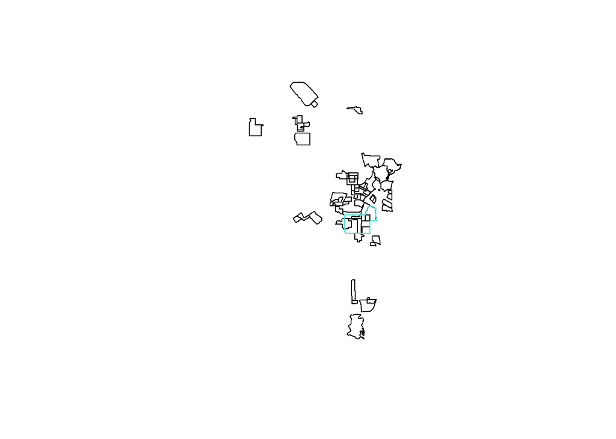

```r
plot(st_geometry(mapSZ))
plot(st_geometry(mapSZ[iMin,]), add=TRUE, col="salmon")
plot(st_geometry(mapSZ[iMax,]), add=TRUE, border="turquoise")
```

The smallest one is very tiny, just to the northeast of the biggest one.

3. Use `st_overlaps(mapSZ, mapSZ, sparse=FALSE)` or `print(st_overlaps(mapSZ, mapSZ, sparse=TRUE), n=Inf, max_nb=Inf)` to find two safety zones that overlap (not just touch at the edges)

```r
print(st_overlaps(mapSZ, mapSZ, sparse=TRUE), n=Inf, max_nb=Inf)
```

```
Sparse geometry binary predicate list of length 65, where the predicate was `overlaps'
 1: (empty)
 2: 57
 3: (empty)
 4: 57
 5: 57
 6: 7, 8
 7: 6, 13, 49
 8: 6
 9: 10, 12
 10: 9, 11, 12, 65
 11: 10, 65
 12: 9, 10
 13: 7
 14: 15, 16, 20, 22, 52, 59, 60, 61, 62
```

[output cut: 51 more lines]

4. With the two safety zones that you found in the previous question, plot using three different colors the first safety zone, second safety zone, and their intersection (hint: use `st_intersection()`)

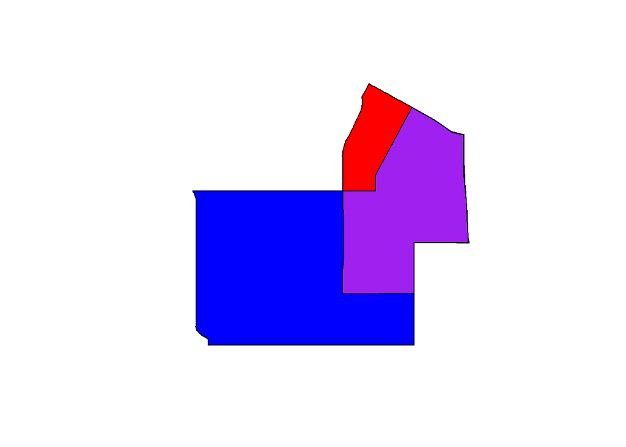

```r
plot(st_geometry(mapSZ[c(30,51),]))
plot(st_difference(st_geometry(mapSZ[30,]),
                   st_geometry(mapSZ[51,])),
     col="red",
     add=TRUE)
plot(st_difference(st_geometry(mapSZ[51,]),
                   st_geometry(mapSZ[30,])),
     col="blue",
     add=TRUE)
plot(st_intersection(st_geometry(mapSZ[51,]),
                     st_geometry(mapSZ[30,])),
     col="purple",
     add=TRUE)
```

5. Census tracts that just touch the boundary of the safety zone are included. To eliminate, rather than use `st_intersects()` with `mapSZms13`, use `st_intersects()` with `st_buffer()` with a negative `dist` to select census tracts

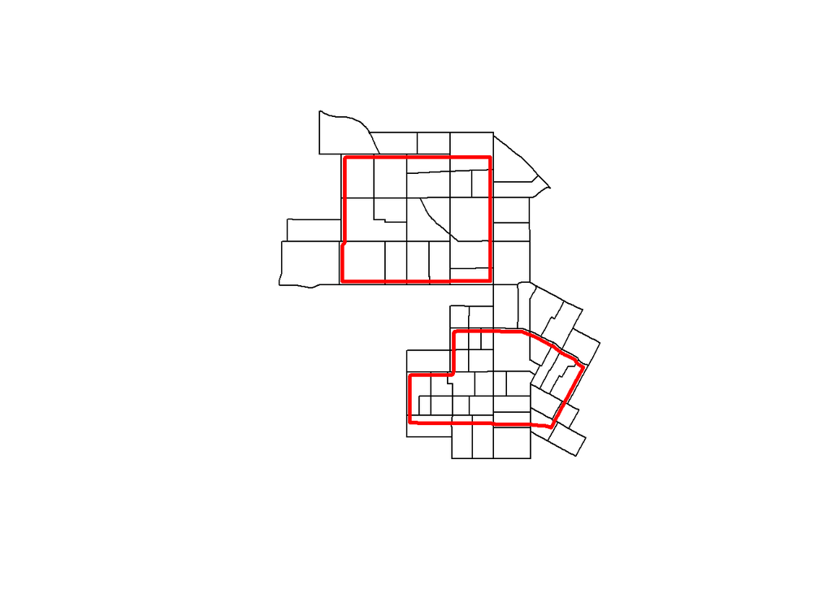

```r
plot(st_geometry(subset(mapCens, inMS13)))
plot(st_geometry(st_buffer(mapSZms13, dist = -200)),
     border="red",
     lwd=3,
     add=TRUE)
```

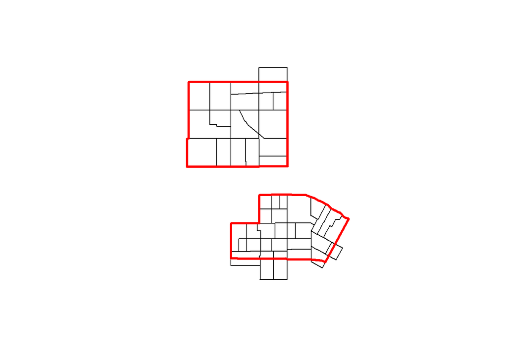

```r
i <- st_intersects(st_buffer(mapSZms13, dist = -200),
                   mapCens)[[1]]
mapCens$inMS13 <- FALSE
mapCens$inMS13[i] <- TRUE
plot(st_geometry(subset(mapCens, inMS13)))
plot(st_geometry(mapSZms13), border="red", lwd=3, add=TRUE)
```

6. Create a map of all census tracts in the City of Los Angeles within 1 mile of one of the safety zones (you choose which safety zone)
7. Color each area based on a census feature (e.g. % non-white, or some other feature from the ACS data)
8. Add the polygon with your injunction zone
9. Add other injunction zones that intersect with your map

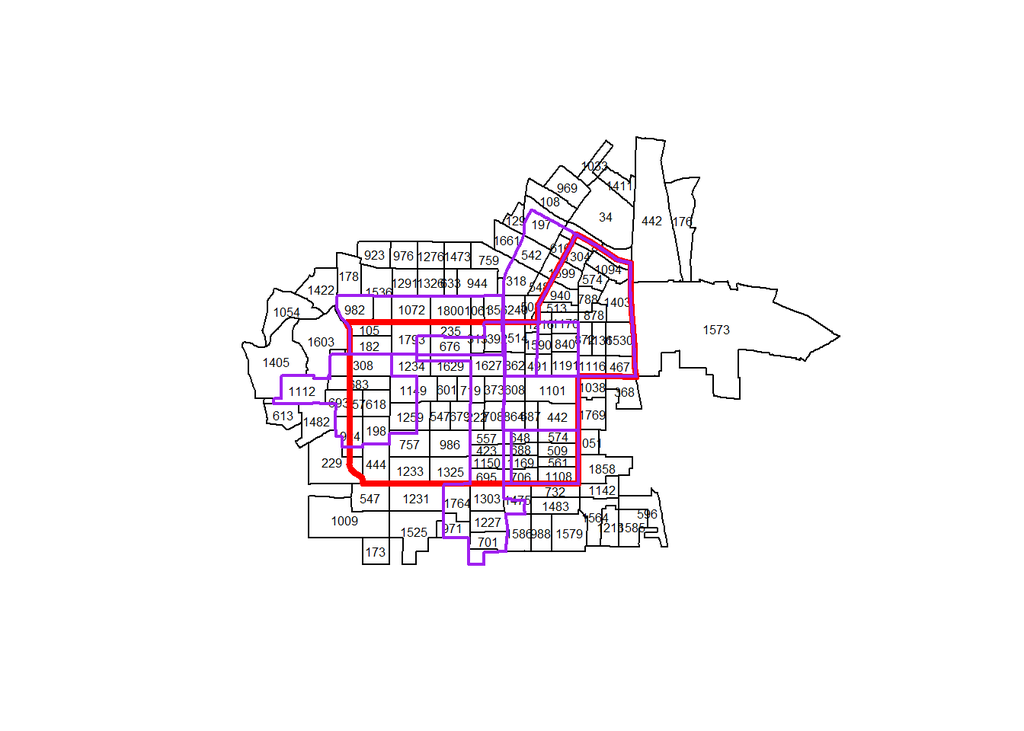

```r
# find census tracts within 1 mile of SZ #51
iCens <- st_intersects(st_buffer(mapSZ[51,], dist=5280),
                   mapCens)[[1]]
plot(st_geometry(mapCens[iCens,]))

# get total population for each census tract
dataRes <- fromJSON(file="http://api.census.gov/data/2014/acs5?get=B03002_001E&for=tract:*&in=state:06+county:037")
dataRes <- data.frame(do.call(rbind, dataRes[-1]))
names(dataRes) <- c("pop","state","county","tract")
dataRes$pop <- as.numeric(dataRes$pop)

# merge population with census tract data
i <- match(mapCens$TRACTCE, dataRes$tract)
mapCens$pop <- dataRes$pop[i]

labs <- mapCens$pop[iCens]
text(st_coordinates(st_centroid(mapCens[iCens,])), labels=labs, cex=0.5)
plot(st_geometry(mapSZ[51,]), add=TRUE, border="red", lwd=4)

# overlay the other intersecting injunctions
i <- st_intersects(mapSZ[51,], mapSZ)[[1]]
# don't include SZ #51 itself in the collection
i <- setdiff(i, 51)
plot(st_geometry(mapSZ[i,]), add=TRUE, border="purple", lwd=2)
```

10. How many 2017 crimes occurred inside safety zones?

```r
i <- st_intersects(st_union(mapSZ),
                   subset(dataCrime, year(mdy(Date.Occurred))==2017))[[1]]
nSZcrimes <- length(i)
```

11. How many crimes per square mile inside safety zones? (Hint 1: use `st_area()` for area), Hint 2: use `st_intersects()` to see which fall inside `mapSZ`)

```r
nSZcrimes / st_area(st_union(mapSZ)) * 5280^2
```

```
950.1118 1/US_survey_foot^2
```

12. How many crimes per square mile outside the safety zone, but within 1 mile of a safety zone

```r
mapBuf <- st_difference(st_buffer(st_union(mapSZ), dist=5280),
                        st_union(mapSZ))
mapBuf <- st_intersection(mapBuf, mapLA)

i <- st_intersects(mapBuf,
                   subset(dataCrime, year(mdy(Date.Occurred))==2017))[[1]]
length(i) / st_area(mapBuf) * 5280^2
```

```
474.3102 1/US_survey_foot^2
```

13. Are there more crimes along Wilshire Blvd or S Vermont Ave?

```r
i <- st_intersects(st_intersection(st_buffer(subset(mapMS13street,
                                                    FULLNAME=="S Vermont Ave"),
                                             dist=100),
                                   mapSZms13s),
                   dataCrime)[[1]]
length(i)
i <- st_intersects(st_intersection(st_buffer(subset(mapMS13street,
                                                    FULLNAME=="Wilshire Blvd"),
                                             dist=100),
                                   mapSZms13s),
                   dataCrime)[[1]]
length(i)
```

```
[1] 2649
[1] 5058
```

14. There are LA Metrorail stations along Wilshire at Western Ave (farthest west), S Normandie Ave, S Vermont Ave, and Alvarado (farthest east). How many crimes occurred within 500ft of a Metrorail station?

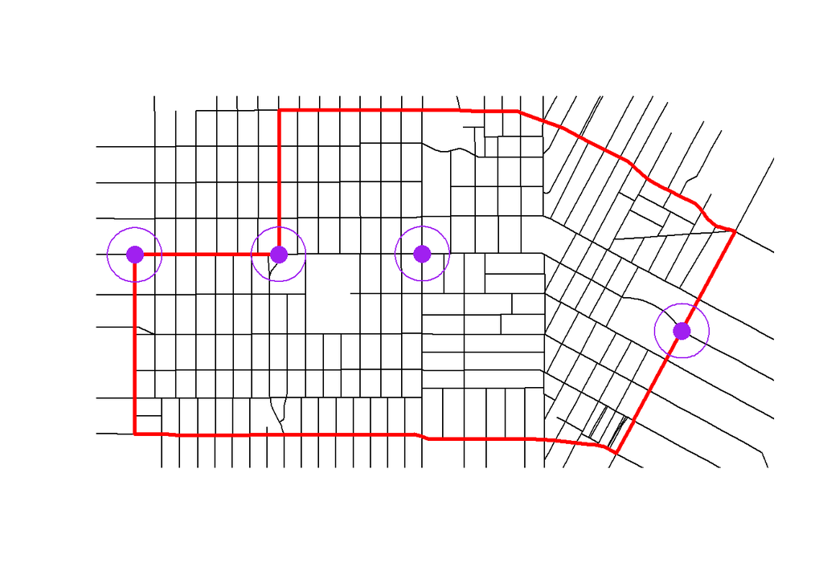

```r
mapMetro <- st_intersection(subset(mapLAstreet, FULLNAME %in%
                             c("S Western Ave","S Normandie Ave",
                               "S Vermont Ave","S Alvarado St")),
                   subset(mapLAstreet, FULLNAME=="Wilshire Blvd"))
plot(st_geometry(mapSZms13s), border="red", lwd=1)
plot(st_geometry(mapMS13street), add=TRUE)
plot(st_geometry(mapSZms13s), border="red", lwd=3, add=TRUE)
plot(st_geometry(mapMetro), col="purple", add=TRUE, pch=16, cex=2)

plot(st_geometry(st_buffer(mapMetro, dist=500)),
     add=TRUE, border="purple")
```

```r
i <- st_intersects(st_buffer(mapMetro, dist=500), dataCrime)
# how many crimes near each station?
sapply(i , length)
# how many crimes overall?
length(unlist(i))
```

```
[1] 991 714 785 467
[1] 2957
```

15. RFK Community Schools occupies the site between Mariposa and Catalina and W 8th St and Wilshire Blvd (former site of the Ambassador Hotel). How many crimes occurred within 500ft of the RFK School?

```r
length(st_intersects(st_buffer(mapRFKschool, dist=500),
                     dataCrimeMS13s)[[1]])
```

```
[1] 3932
```